# Precision Aging Network (PAN) Data Set

## Loading the Data Set

```r
# Ensure the working directory is set correctly
#setwd(dirname(rstudioapi::getActiveDocumentContext()$path))

# Load the data
pan_data <- read_excel("data/KEYS_2024_PAN_data.xlsx")

# Inspect the data
summary(pan_data)
head(pan_data)
```

## Cognitive Function Variable

MoCa Scores that define whether a patient has an MCI or not:

- Unimpaired:
  - MoCa score is greater than 26
- Patients that have a MCI:
  - MoCa score is less than 26

```r
# Check if moca_total_score exists in the data
if ("moca_total_adj" %in% colnames(pan_data)) {
  # Create the dichotomous variable for cognitive function based on MoCA score
  pan_data <- pan_data %>%
    mutate(cognitive_function = ifelse(moca_total_adj < 26, "MCI", "Unimpaired"))

  # Convert cognitive_function to a factor for easier handling in table creation
  pan_data$cognitive_function <- factor(pan_data$cognitive_function, levels = c("Unimpaired", "MCI"))

  # Check the new variable
  print(table(pan_data$cognitive_function))
} else {
  stop("moca_total_adj column not found in the data.")
}
```

```
Unimpaired        MCI
       362        109
```

## Percentage of MCI in PAN:

The percentage of people within the data set have MCI:

```r
# Calculate the percentage of people with MCI
mci_percentage <- sum(pan_data$cognitive_function == "MCI") / nrow(pan_data) * 100
mci_percentage
```

```
[1] 23.14225
```

## Table 1: Demographics Table

This table depicts the distribution of the unimpaired and impaired patients in various demographic aspect:

```r
# Ensure necessary columns are present
required_columns <- c("age", "gender", "race_group", "highest_education_level_completed",
"bio_height", "bio_weight", "bp_l_m_systolic")
missing_columns <- setdiff(required_columns, colnames(pan_data))

if (length(missing_columns) > 0) {
stop(paste("Missing columns:", paste(missing_columns, collapse = ", ")))
}

# Calculate BMI if not already present
pan_data$bio_weight <- as.numeric(pan_data$bio_weight)
pan_data$bio_height <- as.numeric(pan_data$bio_height)
bio_weight_data <- pan_data %>% select(bio_weight)
bio_height_data <- pan_data %>% select(bio_height)
if (!"bmi" %in% colnames(pan_data)) {
pan_data <- pan_data %>%
mutate(bmi=703*(bio_weight_data / (bio_height_data)^2))
}

#pan_data$bmi <- as.numeric(pan_data$bmi)
# Create the Table 1 with demographics
pan_data$bmi <- unlist(pan_data$bmi)
pan_data$bmi <- as.numeric(pan_data$bmi)
pan_data$bp_l_m_systolic <- as.numeric(pan_data$bp_l_m_systolic)
pan_data$bp_l_m_diastolic<- as.numeric(pan_data$bp_l_m_diastolic)

# Add labels to the data for better readability in tables
label(pan_data$age) <- "Current Age"
label(pan_data$gender) <- "Gender"
label(pan_data$race_group) <- "Race/Ethnicity"
label(pan_data$highest_education_level_completed) <- "Highest Education Level"
label(pan_data$bmi) <- "BMI"
label(pan_data$bp_l_m_systolic) <- "Average Left Arm BP Mean (Systolic mm Hg)"
label(pan_data$bp_l_m_diastolic) <- "Average Left Arm BP Mean (Diastolic mm Hg)"

pvalue <- function(x, ...) {
# Construct vectors of data y, and groups (strata) g
y <- unlist(x)
g <- factor(rep(1:length(x), times=sapply(x, length)))
if (is.numeric(y)) {
# For numeric variables, perform a standard 2-sample t-test
p <- t.test(y ~ g)$p.value
} else {
# For categorical variables, perform a chi-squared test of independence
p <- chisq.test(table(y, g))$p.value
}
# Format the p-value, using an HTML entity for the less-than sign.
# The initial empty string places the output on the line below the variable label.
c("", sub("<", "&lt;", format.pval(p, digits=3, eps=0.001)))
}

table1(~ age + gender + race_group + highest_education_level_completed + bmi + bp_l_m_systolic+bp_l_m_diastolic| cognitive_function, data = pan_data, overall = F, extra.col = list("P-value" = pvalue))
```

|  | Unimpaired (N=362) | MCI (N=109) | P-value |
| --- | --- | --- | --- |
| Current Age |  |  |  |
| Mean (SD) | 64.3 (7.39) | 65.4 (8.18) | 0.185 |
| Median [Min, Max] | 65.0 [49.0, 79.0] | 66.0 [50.0, 79.0] |  |
| Gender |  |  |  |
| Female | 250 (69.1%) | 78 (71.6%) | 0.264 |
| Male | 111 (30.7%) | 30 (27.5%) |  |
| NA | 1 (0.3%) | 0 (0%) |  |
| Gender Variant/Non-Conforming | 0 (0%) | 1 (0.9%) |  |
| Race/Ethnicity |  |  |  |
| Hispanic/Latino | 26 (7.2%) | 24 (22.0%) | <0.001 |
| Non-Hispanic Black | 62 (17.1%) | 22 (20.2%) |  |
| Non-Hispanic White | 271 (74.9%) | 57 (52.3%) |  |
| Not Specified | 3 (0.8%) | 6 (5.5%) |  |
| Highest Education Level |  |  |  |
| College Degree (University Graduate) | 140 (38.7%) | 31 (28.4%) | 0.0921 |
| Completed 8th Grade (Elementary or Primary School Graduate) | 1 (0.3%) | 0 (0%) |  |
| High School Diploma (Baccalaureate) | 24 (6.6%) | 8 (7.3%) |  |
| Post Graduate Degree (Masters or Doctorate) | 138 (38.1%) | 39 (35.8%) |  |
| Some College (Some University) | 56 (15.5%) | 29 (26.6%) |  |
| Some High School | 3 (0.8%) | 2 (1.8%) |  |
| BMI |  |  |  |
| Mean (SD) | 26.6 (5.32) | 27.5 (6.70) | 0.224 |
| Median [Min, Max] | 25.4 [16.9, 46.1] | 26.7 [2.08, 50.3] |  |
| Missing | 70 (19.3%) | 1 (0.9%) |  |
| Average Left Arm BP Mean (Systolic mm Hg) |  |  |  |
| Mean (SD) | 133 (18.1) | 133 (19.7) | 0.924 |
| Median [Min, Max] | 131 [90.5, 186] | 133 [85.0, 200] |  |
| Missing | 69 (19.1%) | 2 (1.8%) |  |
| Average Left Arm BP Mean (Diastolic mm Hg) |  |  |  |
| Mean (SD) | 1290 (20800) | 75.0 (11.1) | 0.318 |
| Median [Min, Max] | 74.0 [51.5, 356000] | 75.0 [47.0, 112] |  |
| Missing | 69 (19.1%) | 2 (1.8%) |  |

# Determining What Defines Each Variable

## Tabulate Percentages by Sleep Variables

- This code chunk displays percentages of each type of sleep problems so we can determine which problem is more consist in our sample size:
  - We found that the two significant percentages of sleep problems are: **Sleep Apnea & Sleep Insomnia**
- With our findings we wanted to characterize sleep problems under these two diseases.

```r
# Sleep variables of interest
sleep_vars <- c("sleep_v102", "sleep_v104_1", "sleep_v104_2", "sleep_v104_3", "sleep_v104_4", "sleep_v104_5", "sleep_v104_555", "sleep_v104_6", "sleep_v105")

# Check if all sleep variables are present in pan_data
missing_sleep_vars <- setdiff(sleep_vars, colnames(pan_data))

# Stop execution if any sleep variables are missing
if (length(missing_sleep_vars) > 0) {
  stop(paste("Missing sleep variables:", paste(missing_sleep_vars, collapse = ", ")))
}

# Tabulate percentages for each sleep variable
sleep_percentages <- lapply(pan_data[sleep_vars], function(x) {
  prop.table(table(x)) * 100
})

# Convert to data frame and label variables
sleep_percentages <- lapply(sleep_percentages, function(x) {
  df <- as.data.frame(x)
  # Check the number of rows before assigning row names
  if (nrow(df) == 3) {
    rownames(df) <- c("No", "Yes", "NA")
  }
  return(df)
})

# Assign names to the list elements
names(sleep_percentages) <- c("Do you suffer from insomnia?", "Sleep Apnea", "Restless Leg Syndrome", "Narcolepsy",
                              "REM Sleep Behavior Disorder", "Parasomnias", "Other Sleep Disorders",
                              "Slow Wave Sleep Disorders", "Other Sleep Disorders (Specify)")

# Print sleep percentages
print(sleep_percentages)
```

```
$`Do you suffer from insomnia?`
      x     Freq
No  0.0 36.30573
Yes 1.0 20.38217
NA   NA 43.31210

$`Sleep Apnea`
      x      Freq
No  0.0 68.152866
Yes 1.0  7.006369
NA   NA 24.840764

$`Restless Leg Syndrome`
      x      Freq
No  0.0 73.885350
Yes 1.0  1.273885
NA   NA 24.840764

$Narcolepsy
      x       Freq
No  0.0 74.7346072
Yes 1.0  0.4246285
NA   NA 24.8407643

$`REM Sleep Behavior Disorder`
      x       Freq
No  0.0 74.7346072
Yes 1.0  0.4246285
NA   NA 24.8407643

$Parasomnias
    x     Freq
1 0.0 75.15924
2  NA 24.84076

$`Other Sleep Disorders`
      x      Freq
No  0.0 74.097665
Yes 1.0  1.061571
NA   NA 24.840764

$`Slow Wave Sleep Disorders`
      x       Freq
No  0.0 74.7346072
Yes 1.0  0.4246285
NA   NA 24.8407643

$`Other Sleep Disorders (Specify)`
                                                                          x
1                                    Going to bathroom 3 or 4 times a night
2                   HAD restless leg syndrom years ago.  Don't have it now.
3 I have not been formally diagnosed or examined for it, I am told I snore.
4                                                                        NA
5                                     Snoring that occasionally wakes me up
6                           when wake up, have troubles to fall asleep back
        Freq
1  0.2123142
2  0.2123142
3  0.2123142
4 98.9384289
5  0.2123142
6  0.2123142
```

## Tabulate Percentages by CVD Variables

- This code chunk displays percentages of each type of cardiovascular disease so we can determine which problem is more consist in our sample size:
  - We found that the three significant percentages of sleep problems are: Heart Diseases, Stroke, and Hyper Tension.
- With our findings we wanted to characterize CVD under these three diseases.

```r
# CVD variables of interest
cvd_vars <- c("c19_v1013", "c19_v1014", "c19_v1015")

# Check if all CVD variables are present
missing_cvd_vars <- setdiff(cvd_vars, colnames(pan_data))

if (length(missing_cvd_vars) > 0) {
  stop(paste("Missing CVD variables:", paste(missing_cvd_vars, collapse = ", ")))
}

# Convert CVD columns to numeric (if they are not already)
pan_data[cvd_vars] <- lapply(pan_data[cvd_vars], function(x) as.numeric(as.character(x)))

# Replace 333.0 and 999.0 with NA using dplyr
pan_data <- pan_data %>%
  mutate(across(all_of(cvd_vars), ~ na_if(.x, 333.0))) %>%
  mutate(across(all_of(cvd_vars), ~ na_if(.x, 999.0)))

# Tabulate percentages for each CVD variable
cvd_percentages <- lapply(pan_data[cvd_vars], function(x) {
  prop.table(table(x, useNA = "ifany")) * 100
})

# Convert to data frame and label variables
cvd_percentages <- lapply(cvd_percentages, function(x) {
  df <- as.data.frame(x)
  rownames(df) <- c("No", "Yes", "NA")
  return(df)
})

names(cvd_percentages) <- c("High Blood Pressure", "Heart Disease", "Stroke")

# Print CVD percentages with labels
cvd_percentages
```

```
$`High Blood Pressure`
       x     Freq
No     0 36.30573
Yes    1 19.10828
NA  <NA> 44.58599

$`Heart Disease`
       x      Freq
No     0 48.832272
Yes    1  3.821656
NA  <NA> 47.346072

$Stroke
       x      Freq
No     0 51.167728
Yes    1  1.061571
NA  <NA> 47.770701
```

## Table 2 : Cognitive Function based on Sleep and CVD Variables:

This table depicts the percentage distribution of each sleep problem and cardiovascular disease in terms of unimpaired and MCI.

```r
# Ensure necessary columns are present
required_columns_table2 <- c(sleep_vars,cvd_vars, "bp_l_m_systolic", "bp_l_m_diastolic")
missing_columns_table2 <- setdiff(required_columns_table2, colnames(pan_data))

if (length(missing_columns_table2) > 0) {
  stop(paste("Missing columns for Table 2:", paste(missing_columns_table2, collapse = ", ")))
}

# Add labels for sleep variables
label(pan_data$sleep_v102) <- "Do you suffer from insomnia?"
label(pan_data$sleep_v104_1) <- "Sleep Apnea"
label(pan_data$sleep_v104_2) <- "Restless Leg Syndrome"
label(pan_data$sleep_v104_3) <- "Narcolepsy"
label(pan_data$sleep_v104_4) <- "REM Sleep Behavior Disorder"
label(pan_data$sleep_v104_5) <- "Parasomnias"
label(pan_data$sleep_v104_555) <- "Other Sleep Disorders"
label(pan_data$sleep_v104_6) <- "Slow Wave Sleep Disorders"
label(pan_data$sleep_v105) <- "Other Sleep Disorders (Specify)"

# Add labels for CVD variables
label(pan_data$c19_v1013) <- "High Blood Pressure"
label(pan_data$c19_v1014) <- "Heart Disease"
label(pan_data$c19_v1015) <- "Stroke"

# Create the Table 2 with sleep and CVD variables
table2 <- table1(~ sleep_v102 + sleep_v104_1 + sleep_v104_2 + sleep_v104_3 + sleep_v104_4 + sleep_v104_5 + sleep_v104_555 + sleep_v104_6 + sleep_v105 + c19_v1013 + c19_v1014 + c19_v1015  + bp_l_m_systolic + bp_l_m_diastolic | cognitive_function, data = pan_data)

# Print Table 2
table2
```

|  | Unimpaired (N=362) | MCI (N=109) | Overall (N=471) |
| --- | --- | --- | --- |
| Do you suffer from insomnia? |  |  |  |
| 0.0 | 131 (36.2%) | 40 (36.7%) | 171 (36.3%) |
| 1.0 | 65 (18.0%) | 31 (28.4%) | 96 (20.4%) |
| NA | 166 (45.9%) | 38 (34.9%) | 204 (43.3%) |
| Sleep Apnea |  |  |  |
| 0.0 | 230 (63.5%) | 91 (83.5%) | 321 (68.2%) |
| 1.0 | 24 (6.6%) | 9 (8.3%) | 33 (7.0%) |
| NA | 108 (29.8%) | 9 (8.3%) | 117 (24.8%) |
| Restless Leg Syndrome |  |  |  |
| 0.0 | 252 (69.6%) | 96 (88.1%) | 348 (73.9%) |
| 1.0 | 2 (0.6%) | 4 (3.7%) | 6 (1.3%) |
| NA | 108 (29.8%) | 9 (8.3%) | 117 (24.8%) |
| Narcolepsy |  |  |  |
| 0.0 | 252 (69.6%) | 100 (91.7%) | 352 (74.7%) |
| 1.0 | 2 (0.6%) | 0 (0%) | 2 (0.4%) |
| NA | 108 (29.8%) | 9 (8.3%) | 117 (24.8%) |
| REM Sleep Behavior Disorder |  |  |  |
| 0.0 | 253 (69.9%) | 99 (90.8%) | 352 (74.7%) |
| 1.0 | 1 (0.3%) | 1 (0.9%) | 2 (0.4%) |
| NA | 108 (29.8%) | 9 (8.3%) | 117 (24.8%) |
| Parasomnias |  |  |  |
| 0.0 | 254 (70.2%) | 100 (91.7%) | 354 (75.2%) |
| NA | 108 (29.8%) | 9 (8.3%) | 117 (24.8%) |
| Other Sleep Disorders |  |  |  |
| 0.0 | 249 (68.8%) | 100 (91.7%) | 349 (74.1%) |
| 1.0 | 5 (1.4%) | 0 (0%) | 5 (1.1%) |
| NA | 108 (29.8%) | 9 (8.3%) | 117 (24.8%) |
| Slow Wave Sleep Disorders |  |  |  |
| 0.0 | 253 (69.9%) | 99 (90.8%) | 352 (74.7%) |
| 1.0 | 1 (0.3%) | 1 (0.9%) | 2 (0.4%) |
| NA | 108 (29.8%) | 9 (8.3%) | 117 (24.8%) |
| Other Sleep Disorders (Specify) |  |  |  |
| Going to bathroom 3 or 4 times a night | 1 (0.3%) | 0 (0%) | 1 (0.2%) |
| HAD restless leg syndrom years ago. Don't have it now. | 1 (0.3%) | 0 (0%) | 1 (0.2%) |
| I have not been formally diagnosed or examined for it, I am told I snore. | 1 (0.3%) | 0 (0%) | 1 (0.2%) |
| NA | 357 (98.6%) | 109 (100%) | 466 (98.9%) |
| Snoring that occasionally wakes me up | 1 (0.3%) | 0 (0%) | 1 (0.2%) |
| when wake up, have troubles to fall asleep back | 1 (0.3%) | 0 (0%) | 1 (0.2%) |
| High Blood Pressure |  |  |  |
| Mean (SD) | 0.333 (0.473) | 0.379 (0.489) | 0.345 (0.476) |
| Median [Min, Max] | 0 [0, 1.00] | 0 [0, 1.00] | 0 [0, 1.00] |
| Missing | 167 (46.1%) | 43 (39.4%) | 210 (44.6%) |
| Heart Disease |  |  |  |
| Mean (SD) | 0.0753 (0.265) | 0.0645 (0.248) | 0.0726 (0.260) |
| Median [Min, Max] | 0 [0, 1.00] | 0 [0, 1.00] | 0 [0, 1.00] |
| Missing | 176 (48.6%) | 47 (43.1%) | 223 (47.3%) |
| Stroke |  |  |  |
| Mean (SD) | 0.0272 (0.163) | 0 (0) | 0.0203 (0.141) |
| Median [Min, Max] | 0 [0, 1.00] | 0 [0, 0] | 0 [0, 1.00] |
| Missing | 178 (49.2%) | 47 (43.1%) | 225 (47.8%) |
| Average Left Arm BP Mean (Systolic mm Hg) |  |  |  |
| Mean (SD) | 133 (18.1) | 133 (19.7) | 133 (18.5) |
| Median [Min, Max] | 131 [90.5, 186] | 133 [85.0, 200] | 131 [85.0, 200] |
| Missing | 69 (19.1%) | 2 (1.8%) | 71 (15.1%) |
| Average Left Arm BP Mean (Diastolic mm Hg) |  |  |  |
| Mean (SD) | 1290 (20800) | 75.0 (11.1) | 964 (17800) |
| Median [Min, Max] | 74.0 [51.5, 356000] | 75.0 [47.0, 112] | 74.0 [47.0, 356000] |
| Missing | 69 (19.1%) | 2 (1.8%) | 71 (15.1%) |

## Box Plot

```r
# Create the boxplot for Systolic BP with CVD only
#ggplot(pan_data, aes(x = cognitive_function, y = bp_l_m_systolic, fill = cvd) + geom_boxplot() + labs(title = "Systolic BP by MCI Status and CVD", x = "Cognitive Function", y = "Systolic BP") + theme_minimal()

#ggplot(pan_data, aes(x = cognitive_function, y = bp_l_m_diastolic, fill = cvd)) + geom_boxplot() + labs(title = "Diastolic BP by MCI Status and CVD", x = "Cognitive Function", y = "Diastolic BP") + theme_minimal()
```

## Dichotomous Variables for CVD:

- With our findings we are creating a yes or no variable called cvd_all under the three common diseases

```r
# Create cardiovascular disease variable combining cardiovascular disease, hypertension, and stroke
pan_data$cvd_all <- factor(ifelse(pan_data$c19_v1013== 1 | pan_data$c19_v1014 == 1 | pan_data$c19_v1015 == 1, "Yes", "No"),levels = c("Yes", "No"))

# Check that variable was calculated correctly:
count(pan_data, cvd_all, c19_v1013, c19_v1014, c19_v1015)
```

```
# A tibble: 17 × 5
   cvd_all c19_v1013 c19_v1014 c19_v1015     n
   <fct>       <dbl>     <dbl>     <dbl> <int>
 1 Yes             0         0         1     2
 2 Yes             0         1         0    10
 3 Yes             1         0         0    67
 4 Yes             1         0         1     1
 5 Yes             1         1         0     2
 6 Yes             1         1         1     1
 7 Yes             1         1        NA     5
 8 Yes             1        NA         0     2
 9 Yes             1        NA         1     1
10 Yes             1        NA        NA    11
11 No              0         0         0   151
12 <NA>            0         0        NA     4
13 <NA>            0        NA         0     4
14 <NA>           NA         0         0     4
15 <NA>           NA         0        NA     1
16 <NA>           NA        NA         0     1
17 <NA>           NA        NA        NA   204
```

## Dichotomous Variables for Sleep:

- With our findings we are creating a yes or no variable called sleep problems under the two common diseases

```r
library(dplyr)
pan_data$sleep_v102 <- as.numeric(pan_data$sleep_v102)
pan_data$sleep_v104_1 <- as.numeric(pan_data$sleep_v104_1)

 pan_data$sleep_problems <- factor(ifelse(pan_data$sleep_v102== 1 | pan_data$sleep_v104_1 == 1,"Yes","No"),levels = c("Yes", "No"))

# Display the head of the sleep_problems variable
count(pan_data, sleep_problems,sleep_v102,sleep_v104_1)
```

```
# A tibble: 6 × 4
  sleep_problems sleep_v102 sleep_v104_1     n
  <fct>               <dbl>        <dbl> <int>
1 Yes                     0            1    18
2 Yes                     1            0    81
3 Yes                     1            1    15
4 No                      0            0   153
5 <NA>                   NA            0    87
6 <NA>                   NA           NA   117
```

```r
# Filter out missing observations
dat_filter <- pan_data %>%
  filter(!is.na(cvd_all), !is.na(sleep_problems), !is.na(cognitive_function), race_group != "Not Specified")
```

# Table 1 updated:

This table includes the demographics along with the two new yes or no variables of CVD and sleep.

```r
label(dat_filter$cvd_all) <- "Cardiovascular Disease (CVD, Stroke, Hypertension)"
label(dat_filter$sleep_problems) <- "Sleep Problems"

table1(~  age + gender + race_group +highest_education_level_completed + bmi + bp_l_m_systolic+bp_l_m_diastolic+cvd_all+sleep_problems| cognitive_function,
       data = dat_filter,
       overall = F, extra.col = list("P-value" = pvalue))
```

|  | Unimpaired (N=178) | MCI (N=57) | P-value |
| --- | --- | --- | --- |
| Current Age |  |  |  |
| Mean (SD) | 64.1 (7.20) | 65.6 (8.27) | 0.201 |
| Median [Min, Max] | 64.5 [50.0, 79.0] | 67.0 [50.0, 79.0] |  |
| Gender |  |  |  |
| Female | 123 (69.1%) | 40 (70.2%) | 0.318 |
| Male | 54 (30.3%) | 16 (28.1%) |  |
| NA | 1 (0.6%) | 0 (0%) |  |
| Gender Variant/Non-Conforming | 0 (0%) | 1 (1.8%) |  |
| Race/Ethnicity |  |  |  |
| Hispanic/Latino | 17 (9.6%) | 15 (26.3%) | 0.00119 |
| Non-Hispanic Black | 17 (9.6%) | 9 (15.8%) |  |
| Non-Hispanic White | 144 (80.9%) | 33 (57.9%) |  |
| Highest Education Level |  |  |  |
| College Degree (University Graduate) | 68 (38.2%) | 18 (31.6%) | 0.307 |
| High School Diploma (Baccalaureate) | 10 (5.6%) | 6 (10.5%) |  |
| Post Graduate Degree (Masters or Doctorate) | 72 (40.4%) | 19 (33.3%) |  |
| Some College (Some University) | 27 (15.2%) | 13 (22.8%) |  |
| Some High School | 1 (0.6%) | 1 (1.8%) |  |
| BMI |  |  |  |
| Mean (SD) | 26.4 (5.35) | 26.3 (6.62) | 0.926 |
| Median [Min, Max] | 25.1 [16.9, 46.1] | 26.4 [2.08, 46.2] |  |
| Missing | 2 (1.1%) | 0 (0%) |  |
| Average Left Arm BP Mean (Systolic mm Hg) |  |  |  |
| Mean (SD) | 130 (17.8) | 133 (19.9) | 0.353 |
| Median [Min, Max] | 128 [90.5, 173] | 132 [85.0, 175] |  |
| Missing | 0 (0%) | 1 (1.8%) |  |
| Average Left Arm BP Mean (Diastolic mm Hg) |  |  |  |
| Mean (SD) | 2070 (26600) | 75.3 (11.3) | 0.319 |
| Median [Min, Max] | 74.0 [51.5, 356000] | 75.0 [47.0, 112] |  |
| Missing | 0 (0%) | 1 (1.8%) |  |
| Cardiovascular Disease (CVD, Stroke, Hypertension) |  |  |  |
| Yes | 69 (38.8%) | 25 (43.9%) | 0.597 |
| No | 109 (61.2%) | 32 (56.1%) |  |
| Sleep Problems |  |  |  |
| Yes | 75 (42.1%) | 26 (45.6%) | 0.758 |
| No | 103 (57.9%) | 31 (54.4%) |  |

## Contingency tables :

Contingency tables, also known as cross-tabulations or crosstabs, are used to summarize the relationship between two categorical variables. They display the frequency distribution of the variables and help in understanding the association between them.

- We wanted to use this to see if there is a relationship between sleep problems,cardiovascular diseases, and cognitive function.

```r
# Filter and prepare data for analysis
dat_filter <- pan_data %>%
  filter(!is.na(cognitive_function))

dat_filter$impairment <- factor(ifelse(dat_filter$cognitive_function == "MCI", "Yes", "No"),
                                 levels = c("Yes", "No"))

# Cognitive status by CVD
impair_cvd <- with(dat_filter, table(impairment, cvd_all))

impair_cvd
```

```
          cvd_all
impairment Yes  No
       Yes  28  36
       No   74 115
```

```r
impair_cvd %>% prop.table() %>% round(2)
```

```
          cvd_all
impairment  Yes   No
       Yes 0.11 0.14
       No  0.29 0.45
```

```r
# Cognitive status by Sleep Problems
impair_sleep <- with(dat_filter, table(impairment, sleep_problems))

impair_sleep
```

```
          sleep_problems
impairment Yes  No
       Yes  33  38
       No   81 115
```

```r
impair_sleep %>% prop.table() %>% round(2)
```

```
          sleep_problems
impairment  Yes   No
       Yes 0.12 0.14
       No  0.30 0.43
```

```r
# CVD by Sleep Problems
cvd_all_sleep <- with(dat_filter, table(cvd_all, sleep_problems))

cvd_all_sleep
```

```
       sleep_problems
cvd_all Yes No
    Yes  46 49
    No   57 87
```

```r
cvd_all_sleep %>% prop.table() %>% round(2)
```

```
       sleep_problems
cvd_all  Yes   No
    Yes 0.19 0.21
    No  0.24 0.36
```

# McNemar’s Test:

McNemar’s test is a statistical test used to determine if there are differences in paired proportions. It’s commonly applied to dichotomous (yes/no) variables in pre-post study designs or matched pairs, where the goal is to see if there is a significant change or difference in the proportions of two related groups.

```r
# Cognitive status by CVD
mcnemar.test(impair_cvd)
```

```
    McNemar's Chi-squared test with continuity correction

data:  impair_cvd
McNemar's chi-squared = 12.445, df = 1, p-value = 0.000419
```

```r
# Cognitive status by sleep problems
mcnemar.test(impair_sleep)
```

```
    McNemar's Chi-squared test with continuity correction

data:  impair_sleep
McNemar's chi-squared = 14.824, df = 1, p-value = 0.0001181
```

```r
# CVD by sleep problems
mcnemar.test(cvd_all_sleep)
```

```
    McNemar's Chi-squared test with continuity correction

data:  cvd_all_sleep
McNemar's chi-squared = 0.46226, df = 1, p-value = 0.4966
```

## MCI Plot:

This plot is a visualization of the findings from the mcnemars test and shows all the variables on a graph.

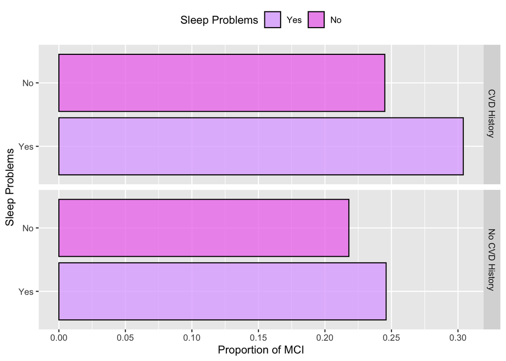

```r
prop_plot_dat <- dat_filter %>%
  select(cognitive_function, cvd_all, sleep_problems) %>%
  drop_na() %>%
  # Get counts of cvd_all x sleep problems for denominator
  group_by(cvd_all, sleep_problems) %>%
  mutate(cvd_all_sleep_counts = n()) %>%
  # Get counts of impairment x cvd_all x sleep problems for numerator
  group_by(cognitive_function, .add = TRUE) %>%
  mutate(group_counts = n()) %>%
  distinct() %>%
  # Just get proportion of MCI for each group
  filter(cognitive_function == "MCI") %>%
  mutate(props = round(group_counts / cvd_all_sleep_counts, 3),
         cvd_all = ifelse(cvd_all == "Yes", "CVD History ",
                          "No CVD History"))

# Check counts
# count(dat_filter, cognitive_function, cvd_all, sleep_problems)

ggplot(prop_plot_dat, aes(x = sleep_problems, y = props, fill = sleep_problems)) +
  geom_bar(stat = "identity", alpha = 0.8, color = "black") +
  labs(x = "Sleep Problems", y = "Proportion of MCI", fill = "Sleep Problems") +
  coord_flip() +
  facet_grid(rows = vars(cvd_all)) +
  # Increase proportion axis ticks
  scale_y_continuous(breaks = scales::pretty_breaks(n = 10)) +
  scale_fill_manual(values = c("Yes" = "#E0B0FF", "No" = "#EE82EE")) +
  theme(legend.position = "top")
```

## Statistical Analysis

We wanted to run a logistic regression model as well to ensure our results from the McNemar’s test and the model depicted the same conclusion. Further, we also compared other factors such as age and the patients’ education to see if these aspects also played apart in our conclusion.

```r
library(rms)
ddd <- datadist(pan_data)
options( datadist = "ddd" )

model1 <- lrm(cognitive_function ~ sleep_problems, data= dat_filter, x=TRUE, y=TRUE )
anova(model1)
```

```
                Wald Statistics          Response: cognitive_function

 Factor         Chi-Square d.f. P
 sleep_problems 0.56       1    0.4524
 TOTAL          0.56       1    0.4524
```

```r
model2 <-lrm(cognitive_function ~ cvd_all+sleep_problems, data=dat_filter,  x=TRUE, y=TRUE)
anova(model2)
```

```
                Wald Statistics          Response: cognitive_function

 Factor         Chi-Square d.f. P
 cvd_all        0.51       1    0.4744
 sleep_problems 0.51       1    0.4753
 TOTAL          1.12       2    0.5726
```

```r
model3 <- lrm(cvd_all ~ sleep_problems, data=dat_filter, x=TRUE, y=TRUE)
anova(model3)
```

```
                Wald Statistics          Response: cvd_all

 Factor         Chi-Square d.f. P
 sleep_problems 1.82       1    0.1776
 TOTAL          1.82       1    0.1776
```

```r
model6 <- lrm(cognitive_function ~ race_group, data=dat_filter,  x=TRUE, y=TRUE)
model6
```

```
Logistic Regression Model

lrm(formula = cognitive_function ~ race_group, data = dat_filter,
    x = TRUE, y = TRUE)

                       Model Likelihood      Discrimination    Rank Discrim.
                             Ratio Test             Indexes          Indexes
Obs           471    LR chi2      29.35      R2       0.091    C       0.629
 Unimpaired   362    d.f.             3      R2(3,471)0.054    Dxy     0.259
 MCI          109    Pr(> chi2) <0.0001    R2(3,251.3)0.100    gamma   0.464
max |deriv| 3e-07                            Brier    0.165    tau-a   0.092

                              Coef    S.E.   Wald Z Pr(>|Z|)
Intercept                     -0.0800 0.2831 -0.28  0.7774
race_group=Non-Hispanic Black -0.9560 0.3764 -2.54  0.0111
race_group=Non-Hispanic White -1.4790 0.3184 -4.65  <0.0001
race_group=Not Specified       0.7732 0.7617  1.02  0.3100
```

```r
anova(model6)
```

```
                Wald Statistics          Response: cognitive_function

 Factor     Chi-Square d.f. P
 race_group 29.17      3    <.0001
 TOTAL      29.17      3    <.0001
```

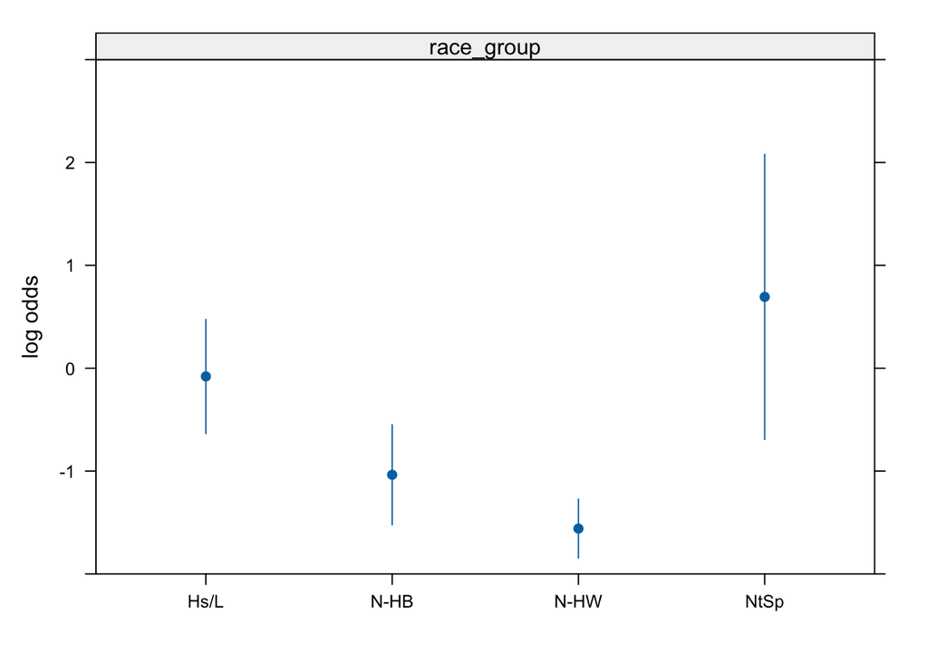

```r
plot(Predict(model6))
```

```r
library(stargazer)


stargazer(model1, model2, model6, title="Regression Results", model.numbers=FALSE, column.labels=c("Model 1", "Model 2", "Model 3"), type="text", out="regression_results.html")
```

```
Regression Results
==============================================================================
                                            Dependent variable:
                              ------------------------------------------------
                                             cognitive_function
                                 Model 1        Model 2          Model 3
------------------------------------------------------------------------------
cvd_all=No                                       -0.218
                                                (0.305)

sleep_problems=No                 -0.209         -0.216
                                 (0.279)        (0.303)

race_group=Non-Hispanic Black                                    -0.956**
                                                                 (0.376)

race_group=Non-Hispanic White                                   -1.479***
                                                                 (0.318)

race_group=Not Specified                                          0.773
                                                                 (0.762)

Constant                        -0.898***      -0.867***          -0.080
                                 (0.207)        (0.274)          (0.283)

------------------------------------------------------------------------------
Observations                       267            239              471
R2                                0.003          0.007            0.091
chi2                          0.563 (df = 1) 1.114 (df = 2) 29.353*** (df = 3)
==============================================================================
Note:                                              *p<0.1; **p<0.05; ***p<0.01
```